[figure not shown]

# Programming Language (Training at SAC)

## Introduction

#### **Name**: S. Devakanth Naidu

#### **Division**: High Resolution Data Processing Division (SIPG)

# Overview

- Introduction to Python
- Numbers, Strings and Lists
- Built in Constants, Data Types and Functions
- Control Flow (Conditional and Loops)
- Functions
- Data Structures
- Modules and Packages
- String Formatting
- Reading Writing Files
- Errors and Exceptions
- Classes
- Iterators and Generators

## Questions

- Programming
- Languages
- software development
- object oriented programming
- architectures
- design patterns
- unit testing
- version control

[figure not shown]

# Python Programing Language

## What is python

- High Level, general purpose programming language

# Who created Python?

- Guido van Rossum (born 1956)

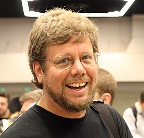

# Guido van Rossum

- Dutch programmer
- Master's degree in Mathematics and Computer Science from University of Amsterdam in 1982
- Worked in many research institutes
- Zope corporation (2000-2003), **Google (2005 - 2012)**
- Dropbox (2013 - 2019), Retired
- Microsoft (Distinguished Engineer) (2020 - Till date)

## History

- December 1989, Hobby project for Christmas
- Name: Monty Python's Flying Circus, British comedy series
- Releases
  - First release: 1991 (Ver 0.9.0)
  - 2.0: 2000
  - 3.0: 2008
  - 2.7.18: 2020 (Last release of 2) (initially planned 2015)
  - Current release: 3.11.2

# Features

- Strongly typed
- Dynamically typed
- Garbage collected
- Everything is an object
- Programming paradigms
  - Structured/Procedural
  - Object oriented
  - Functional
  - Metaprogramming
- "Batteries included": Extensive standard library
- Readability counts. Indentation

## Python's popularity

- No. of programming languages

250-9000

https://en.wikipedia.org/wiki/List_of_programming_languages

- Top 10

https://www.tiobe.com/tiobe-index/

[figure not shown]

[figure not shown]

# Advantages

- **Ease of Use**
  - Simple, concise, and straightforward syntax.
  - Looks like plain English. Highly readable code. Programs easy to read and debug.
  - Control structures are **intuitive**, easy to use.
  - **Dynamically typed**, No requirement to declare variable type
  - Python is one of the most efficient and productive languages
- **Gentle Learning Curve**
  - Is a good option for people **learning to program**.
  - Programmers **coming from C or Java** can quickly reach peak efficiency.
  - Many **Development Environments**

# Advantages

- **Versatility**
  - Flexible, general purpose language. Supports both procedural, object-oriented and functional programming.
  - Built-in and third-party packages, Suitable for a **wide range of tasks**
  - Dominant in the areas of **data science and machine learning**
  - Widely used for back-end **web development and the Internet of Things (IoT)**
  - Python code can be **embedded into projects** written in other languages
  - Code from other languages can be **embedded in Python**
- **Efficient for Rapid Development**
  - Easy to use, **no need to compile**, Less Development time.
  - Programs are **shorter** than equivalent programs in other languages.
  - Can quickly construct **prototypes** in a rapid software development environment.
- **True Portability** - Windows, Linux, Mac

# Advantages

- **Automatic Memory Allocation**
  - No **pointers**!
  - Allocates memory automatically, garbage collector recycles memory
  - Developers need not worry about **memory leaks**, invalid pointer references, or the size of each object.
- **Extensive Built-In Libraries**
- **Extensive Third-Party Libraries**
- **Open Source and Free to Use**
- **Large User Base**
  - Large, active, and passionate community of users
  - Easy to find **learning materials** and other resources, ask questions, search for jobs, hire additional developers, and meet other Python programmers.

# Disadvantages of Python

- **Not Very Fast**
  - **Slower** than more efficient languages like C and Java
  - Run-time compiler has a lot of work to do
- **Memory Intensive**
  - Not optimized to reduce memory
- **Harder to Avoid Runtime Errors**
  - Not compiled so many problems are visible **only when program runs**
- **Mobile or Desktop Applications**
  - Not popular in **mobile development**
  - Not popular in **desktop apps**
- **Not Optimized for Database Access**
  - Ok for straightforward DB access but not the best choice for **large databases**
- **No True Multithreading Support**
  - GIL
- **Prone to Overuse or Misuse**
  - Easy to use so many times used in areas not suitable

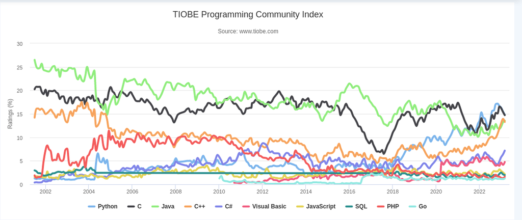

# Features Comparison

| Aspect | C++ | Java | Python |
| --- | --- | --- | --- |
| Typing | Strong, Static | Strong, Static | Strong, Dynamic |
| Compiled vs. Interpreted | Compiled | Compiled and Interpreted | Interpreted |
| Platform Dependence | platform dependent | platform-independent | platform-independent |
| Operator Overloading | supports operator overloading | does not support operator overloading | Python supports operator overloading |
| Inheritance | provides both single and multiple inheritances | single inheritance is possible while multiple inheritances can be achieved using Interfaces | Python provides both single and multiple inheritances |
| Execution Time | very fast | much faster than Python in terms of speed of execution but slower than C++. | slow in terms of execution |
| Program Handling | Functions and variables are used outside the class | variables and functions has to be inside the class | Functions and variables can be declared and used outside the class |
| Library Support | has relatively limited library support | Library support for many concepts like UI | Has a huge set of libraries and modules. |
| Code Length | Code length is lesser than Java, around 1.5 times less. | Code length is bigger than Python and C++. | Smaller code length |

## Areas of applications. where it is used

- Data science
- Scientific and mathematical computing
- Web development
- Finance and trading
- System automation and administration
- Computer graphics
- Basic game development
- Security and penetration testing
- General and application-specific scripting
- Mapping and geography (GIS software)

# Companies using Python

- Intel
- IBM
- **NASA**
- Pixar
- Netflix
- Facebook
- Spotify
- **Google**
- YouTube
- Reddit
- Pinterest
- Instagram
- Industrial light and magic
- Quora
- Amazon
- Uber
- Dropbox and Paypal

# Implementations

- CPython
- Jython
- PyPy
- IronPython - Python in C# for the Common Language Runtime (CLR/.NET) and the FePy project's IronPython Community Edition (IPCE)
- pyjs - (formally Pyjamas) a Python to JavaScript compiler plus Web/GUI framework
- PyMite - Python for embedded devices
- tinypy - a minimalist implementation of Python in 64K of code

https://wiki.python.org/moin/PythonImplementations

## Installation

- Python https://www.python.org/downloads/
  - Windows
  - Linux
- pip: Package installer https://pypi.org/
- Anaconda https://www.anaconda.com/products/distribution
  - Repository

[figure not shown]

  - Conda: package manager
  - Anaconda Navigator
  - Cloud
  - Enterprise

## Development environment

- "Data analysis and protytping environment"
- Read Evaluate Print Loop (REPL)
- Command prompt
- IDLE
- Qt Console
- Spyder
- Pycharm
- VSCode
- Jupyter Notebook/Lab

# Brief Intro to Jupyter Notebook

- Server - Client (Web browser)
- Cells
- Run

# How to Learn Python?

https://www.youtube.com/watch?v=F2Mx-u7auUs&t=23s